# ggplot Workshop

## Time series

To plot time series, we might have to change the format of our dataset. Have a look at the inbuilt dataset uspop:

```r
str(uspop)
```

```
##  Time-Series [1:19] from 1790 to 1970: 3.93 5.31 7.24 9.64 12.9 17.1 23.2 31.4 39.8 50.2 ...
```

```r
uspop
```

```
## Time Series:
## Start = 1790
## End = 1970
## Frequency = 0.1
##  [1]   3.93   5.31   7.24   9.64  12.90  17.10  23.20  31.40  39.80  50.20
## [11]  62.90  76.00  92.00 105.70 122.80 131.70 151.30 179.30 203.20
```

It is in a different format to the data we used so far. First we need to ensure that year and the values are both variables:

```r
uspop2 <- data.frame(Year = c(time(uspop)), Value = c(uspop))
# this turns the time values of uspop into the variable Year, and the other values into variable Value, in the new dataset uspop2
```

Now we can use the data to plot the population over time:

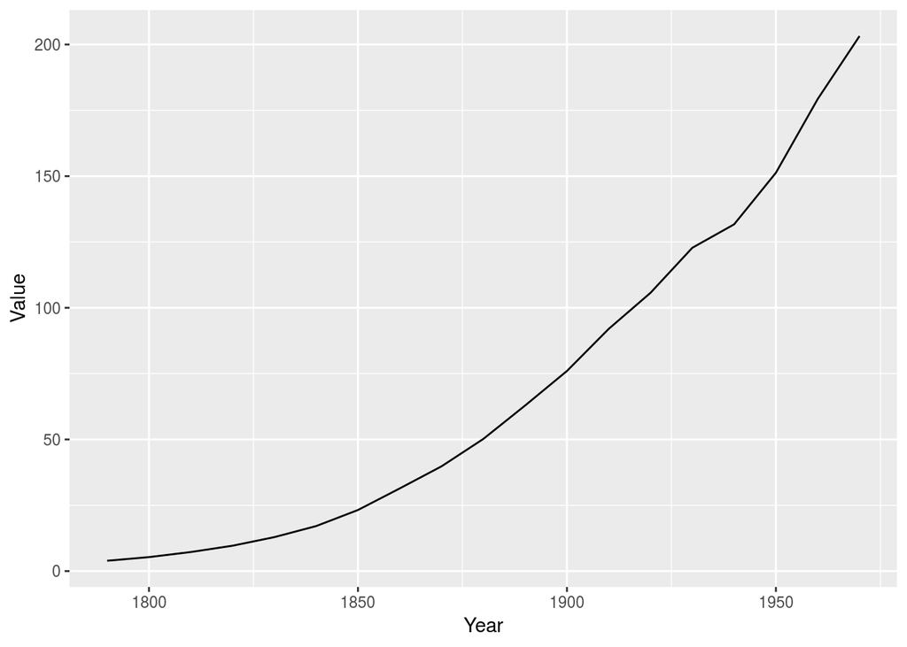

```r
ggplot(data=uspop2, aes(x=Year, y=Value)) + geom_line()
```

We can also add points for each year in addition to the line:

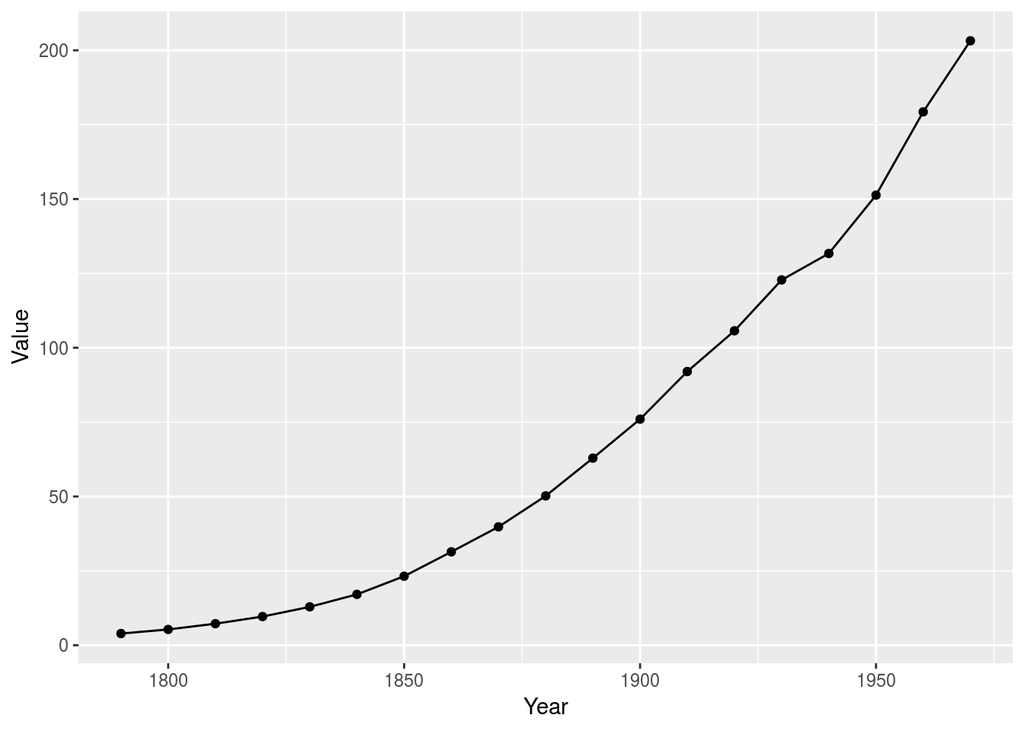

```r
ggplot(data=uspop2, aes(x=Year, y=Value)) + geom_line() + geom_point()
```

## Facets

One very useful feature of ggplot2 is the use of facets, where we split the data into subgroups, depending on a categorical variable, and make individual plots for each group. We can do this very easily by just adding a little bit of code. We will use our boxplot from earlier again to see how the facetting changes the plot:

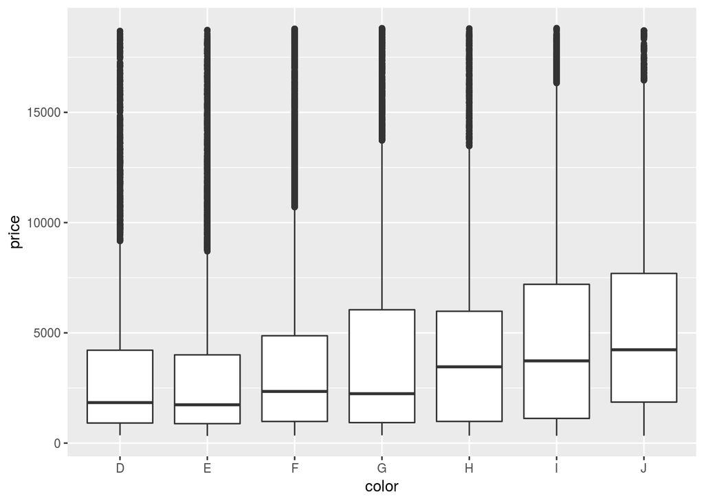

```r
ggplot(data=diamonds, aes(x=color, y=price)) + geom_boxplot()
```

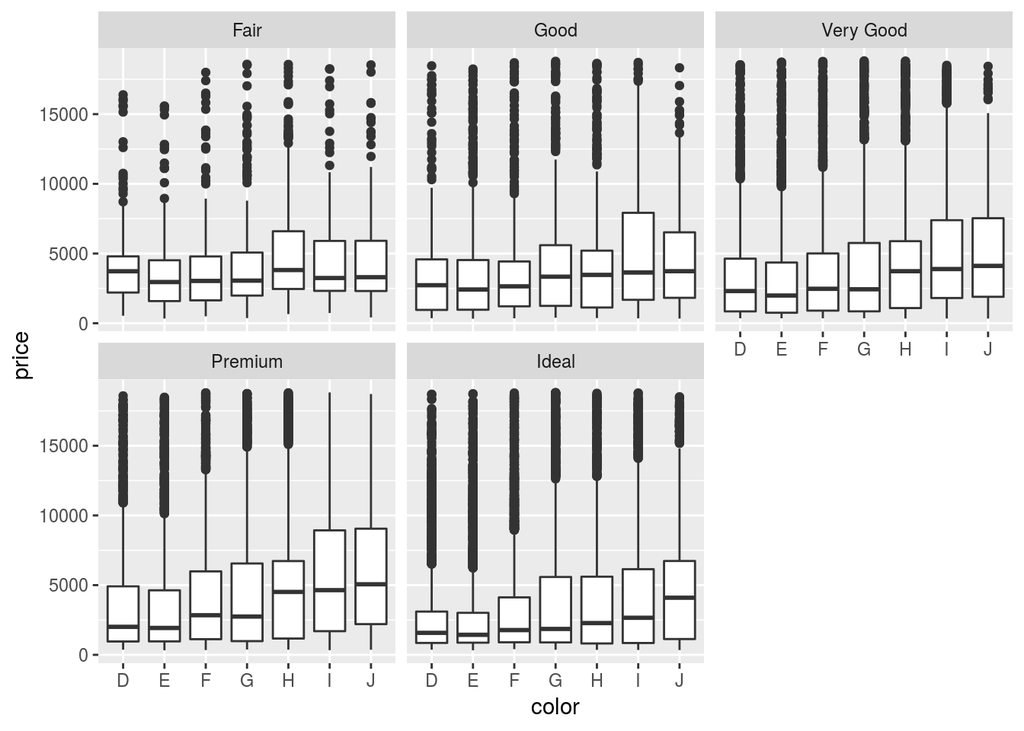

```r
ggplot(data=diamonds, aes(x=color, y=price)) + geom_boxplot() + facet_wrap(~cut)
```

`facet_wrap()` can be arranged by specifying the number of rows or columns with `nrow` or `ncol`:

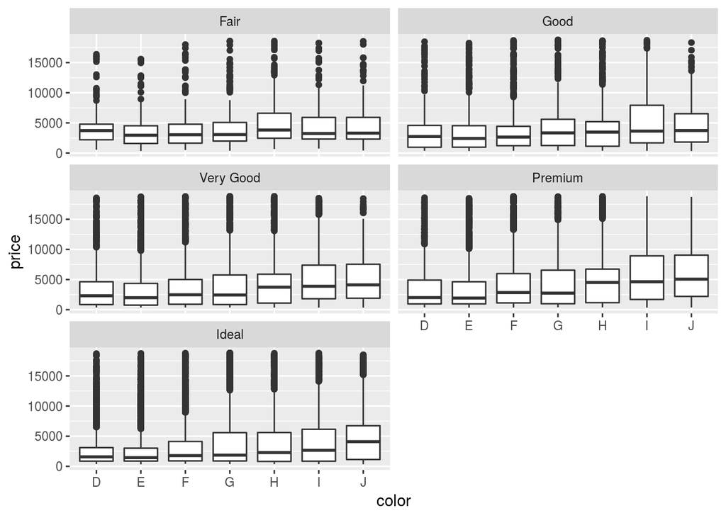

```r
ggplot(data=diamonds, aes(x=color, y=price)) + geom_boxplot() + facet_wrap(~cut, nrow=3)
```

`facet_grid()` on the other hand always arranges the plots in a grid:

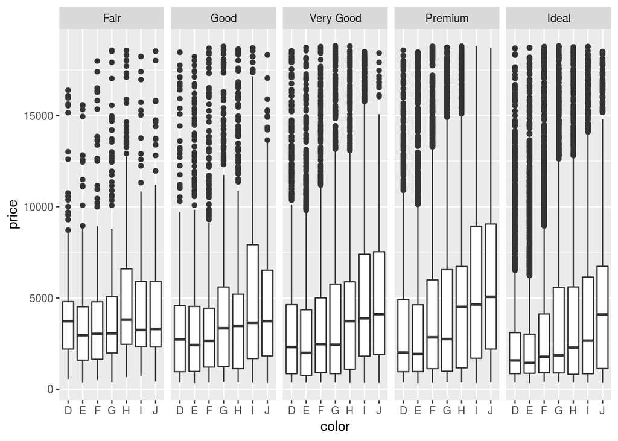

```r
ggplot(data=diamonds, aes(x=color, y=price)) + geom_boxplot() + facet_grid(~cut)
```

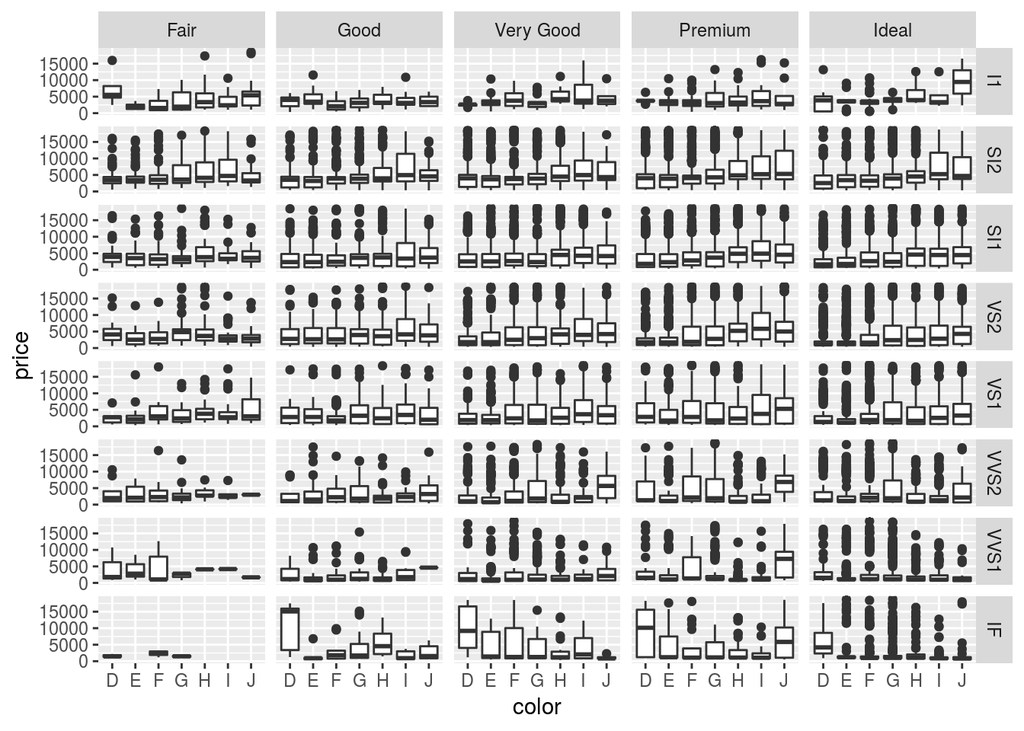

```r
ggplot(data=diamonds, aes(x=color, y=price)) + geom_boxplot() + facet_grid(clarity~cut)
```

## A completely custom ggplot2 theme

Now you know how to make plots in ggplot2 with the default settings, you can start to make customised plots by changing the theme. This will not change how the data are displayed, but how the plot itself looks. It is useful if you want all plots in your thesis to have the same look.

Here is an example of a customised plot, with annotation for the code:

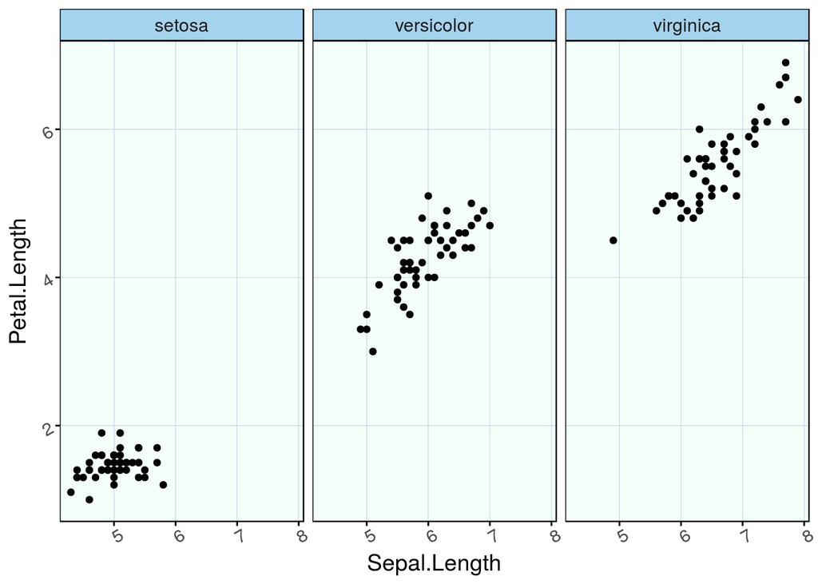

```r
ggplot(data=iris, aes(x=Sepal.Length, y=Petal.Length)) + geom_point() + facet_wrap(~Species)+
scale_colour_gradient(low="green", high="blue", name="Petal width")+
# this is similar to a plot we made earlier
theme(text= element_text(size=14),
# this changes the font size to 14
axis.text = element_text(angle=30, size = rel(0.8)),
# this changes the angle of the axis labels (often useful for bar plots), and makes the font slightly smaller than the rest of the plot
axis.ticks = element_line(colour = "black"),
plot.background = element_rect(fill="white"),
#this is the colour behind the plot
panel.background = element_rect(fill = "mintcream"),
# this is the colour inside the plots
panel.border = element_rect(fill = NA, colour = "black"),
panel.grid.major = element_line(colour = "lightskyblue3", size = .1),
panel.grid.minor = element_line(colour = "mintcream"),
# the minor grid lines - same colour as each panel
strip.background = element_rect(fill = "lightskyblue2", colour = "black", size = 0.5))#this refers to the box with the heading above each facet
```

## Saving a plot

Your plots will be saved in the folder that you set as your working directory. This line of code will save the last ggplot you made to a pdf:

```r
ggsave("plot.pdf")
```

Or you can save it as a jpg:

```r
ggsave("plot.jpg")
```

You can specify the size by adding dpi. You can also specify the exact width and height (in inches) which is useful for publications:

```r
ggsave("plot.pdf", dpi=300, width=5, height=5)
```

## Additional packages

There are a lot of other packages in R now that add more functionality to ggplot2. Have a look at the ggplot2 extensions website (http://www.ggplot2-exts.org/gallery/) and see whether any of the packages might be useful for your own work. There are packages with more themes (for example ggthemes), a package for making animated graphs (gganimate), packages for plotting graph structures (for example ggraph) and so on.